# Missing Data

Syed Jafar Raza Rizvi NSID: cfr954 Student ID: 11344782

2025-02-11

# 1. **Dataset Exploration**

- Load the provided health administrative dataset.
- Explore the dataset to identify the extent, patterns, and potential reasons for missing data.
- Summarize findings using tables, charts, or heatmaps to visualize missingness.

## - Load the provided health administrative dataset.

```r
data<-read.csv("can_path_data.csv")
# data <- data %>% select(ID:HS_GEN_HEALTH, PA_TOTAL_SHORT, PM_BMI_SR, contains("_EVER"), contains("WRK_"))
```

## - Explore the dataset to identify the extent, patterns, and potential reasons for missing data.

### Explore Dataset

**Check the structure of the dataset**

```r
dim(data)
```

```
## [1] 41187   440
```

```r
df_info <- data.frame(
  Variable = names(data),
  Type = sapply(data, class)  # Gets the data type of each variable
)
print(df_info, row.names = FALSE)  # Print full output
```

```
##                             Variable      Type
##                                   ID character
##                         ADM_STUDY_ID   integer
##                           SDC_GENDER   integer
##                         SDC_AGE_CALC   integer
##                   SDC_MARITAL_STATUS   integer
##                        SDC_EDU_LEVEL   integer
##                    SDC_EDU_LEVEL_AGE   integer
##                           SDC_INCOME   integer
##                    SDC_INCOME_IND_NB   integer
##              SDC_HOUSEHOLD_ADULTS_NB   integer
##            SDC_HOUSEHOLD_CHILDREN_NB   integer
##                        HS_GEN_HEALTH   integer
##                HS_ROUTINE_VISIT_EVER   integer
##                HS_ROUTINE_VISIT_LAST   integer
##                 HS_DENTAL_VISIT_EVER   integer
##                 HS_DENTAL_VISIT_LAST   integer
##                         HS_FOBT_EVER   integer
##                         HS_FOBT_LAST   integer
##                          HS_COL_EVER   integer
##                          HS_COL_LAST   integer
##                          HS_SIG_EVER   integer
##                          HS_SIG_LAST   integer
##                      HS_SIG_COL_EVER   integer
##                      HS_SIG_COL_LAST   integer
##                        HS_POLYP_EVER   integer
##                          HS_PSA_EVER   integer
##                          HS_PSA_LAST   integer
##                 MH_CHILDREN_FATHERED   integer
##                  WH_MENSTRUATION_AGE   integer
##               WH_CONTRACEPTIVES_EVER   integer
##                WH_CONTRACEPTIVES_AGE   integer
##           WH_CONTRACEPTIVES_DURATION   integer
##                         WH_GRAVIDITY   integer
##                    WH_PREG_FIRST_AGE   integer
##                          WH_PREG_CUR   integer
##                       WH_PREG_CUR_WK   integer
##                     WH_PREG_LAST_AGE   integer
##            WH_BREASTFEEDING_DURATION   integer
##                          WH_HFT_EVER   integer
```

[output cut: 386 more lines]

```
##                          WTHNRC15_05   numeric
##                          WTHNRC15_07   numeric
##                          WTHNRC15_08   integer
##                          WTHNRC15_09   integer
##                          WTHNRC15_10   numeric
##                          WTHNRC15_11   numeric
##                          WTHNRC15_12   numeric
##                          WTHNRC15_13   integer
##                          WTHNRC15_14   integer
##                          WTHNRC15_15   numeric
##                          WTHNRC15_16   numeric
##                          WTHNRC15_17   integer
##                          WTHNRC15_18   integer
##                          WTHNRC15_19   numeric
##                          LGTNLT12_01   integer
```

In this health administrative dataset, there are 41,187 observations and 440 variables. Most of these variables are integers, numeric, or character, which makes sense. However, some variables are being treated as logical. Let’s identify those logical variables.

```r
data %>%
  select_if(is_logical) %>%
  glimpse()
```

```
## Rows: 41,187
## Columns: 9
## $ DIS_GEN_DS_EVER          <lgl> NA, NA, NA, NA, NA, NA, NA, NA, NA, NA, NA, N…
## $ DIS_GEN_SCA_EVER         <lgl> NA, NA, NA, NA, NA, NA, NA, NA, NA, NA, NA, N…
## $ DIS_GEN_THALASSEMIA_EVER <lgl> NA, NA, NA, NA, NA, NA, NA, NA, NA, NA, NA, N…
## $ DIS_GEN_CAH_EVER         <lgl> NA, NA, NA, NA, NA, NA, NA, NA, NA, NA, NA, N…
## $ DIS_GEN_AIS_EVER         <lgl> NA, NA, NA, NA, NA, NA, NA, NA, NA, NA, NA, N…
## $ DIS_GEN_HEMOPHILIA_EVER  <lgl> NA, NA, NA, NA, NA, NA, NA, NA, NA, NA, NA, N…
## $ DIS_GEN_CF_EVER          <lgl> NA, NA, NA, NA, NA, NA, NA, NA, NA, NA, NA, N…
## $ DIS_GEN_KS_EVER          <lgl> NA, NA, NA, NA, NA, NA, NA, NA, NA, NA, NA, N…
## $ DIS_GEN_TS_EVER          <lgl> NA, NA, NA, NA, NA, NA, NA, NA, NA, NA, NA, N…
```

We have 9 variables that are logical so let’s drop those.

```r
### Select specific columns
logical_cols <- c("DIS_GEN_DS_EVER", "DIS_GEN_SCA_EVER", "DIS_GEN_THALASSEMIA_EVER", "DIS_GEN_CAH_EVER", "DIS_GEN_AIS_EVER", "DIS_GEN_HEMOPHILIA_EVER", "DIS_GEN_CF_EVER", "DIS_GEN_KS_EVER", "DIS_GEN_TS_EVER")

data <- data %>% select(!(logical_cols))
```

**Identify Missing Data**

```r
missing_table <- miss_var_summary(data)
missing_table
```

```
## # A tibble: 431 × 3
##    variable                       n_miss pct_miss
##    <chr>                           <int>    <num>
##  1 DIS_CARDIO_PREM_HD_FEMALE_EVER  41081     99.7
##  2 DIS_CARDIO_PREM_HD_MALE_EVER    41061     99.7
##  3 DIS_MH_BIPOLAR_EVER             40914     99.3
##  4 DIS_EAR_TINNITUS_NATURE         40880     99.3
##  5 DIS_ENDO_TD_AGE                 40862     99.2
##  6 DIS_ENDO_SUGAR_AGE              40861     99.2
##  7 DIS_RESP_OTHER_EVER             40858     99.2
##  8 DIS_MH_EATING_EVER              40857     99.2
##  9 DIS_LIVER_FATTY_EVER            40856     99.2
## 10 DIS_EAR_TINNITUS_FREQ           40854     99.2
## # ℹ 421 more rows
```

Although the proportion of missing data can influence statistical inference, there are no universally accepted guidelines for the maximum amount of missing data for which multiple imputation (MI) remains beneficial. One study suggests that when over 10% of data are missing, the estimates may become biased (Bennett 2001). Another paper proposes 5% as a threshold, below which MI is unlikely to provide significant benefits (Schafer 1999). However, limited evidence exists to support these cutoff points. Few studies have explored how bias and efficiency change with increasing levels of missing data, with the most extreme case being 50% missing data, which showed growing inconsistency in effect estimates as missingness increased (Mishra and Khare 2014) for the small sample. However, when both high missing data and large sample sizes are considered as missing data being at random (MAR) (Lee and Carlin 2012). In this analysis, I consider missing values with less than 50 percent in this dataset.

let’s review filter out all variables with more than 50% missing.

```r
data <- data %>%
          select(where(~sum(is.na(.x))/length(.x) < 0.50))

missing_table <- miss_var_summary(data)
```

```r
missing_table <- miss_var_summary(data)
missing_table
```

```
## # A tibble: 232 × 3
##    variable              n_miss pct_miss
##    <chr>                  <int>    <num>
##  1 PM_WAIST_HIP_RATIO_SR  17734     43.1
##  2 PM_HIP_SR_AVG          17349     42.1
##  3 WH_MENSTRUATION_AGE    17026     41.3
##  4 PM_WAIST_SR_AVG        16400     39.8
##  5 HS_PAP_EVER            16182     39.3
##  6 HS_MMG_EVER            15995     38.8
##  7 PM_BMI_SR              11976     29.1
##  8 PM_WEIGHT_SR_AVG       11707     28.4
##  9 PA_TOTAL_SIT_TIME      11272     27.4
## 10 PA_SIT_AVG_TIME_DAY    11257     27.3
## # ℹ 222 more rows
```

### Summarize findings using tables, charts, or heatmaps to visualize missingness.

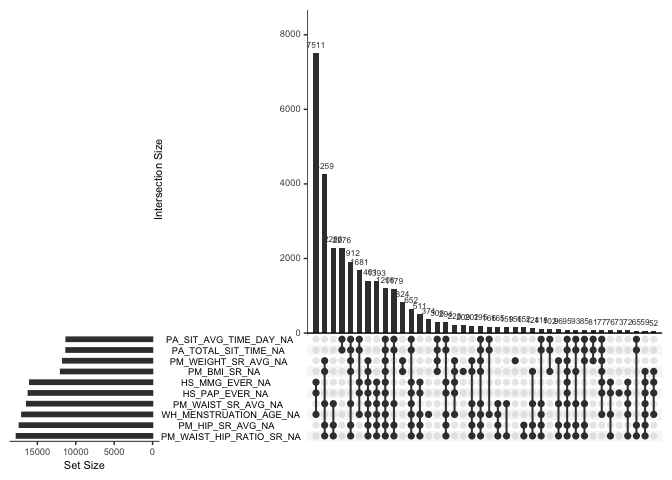

```r
gg_miss_upset(data, order.by = "freq", nsets = 10)
```

Suppose we want to make model where We have identified the outcome and predictors variable. Follwoing are the outcoma and predictor variables.

## Main Outcome of Interest:

BMI: Body Mass Index (PM_BMI_SR).

## Expouser

PA: Physical Activities: PA_TOTAL_SHORT

SL: Sedentary lifestyle: Total sitting time per week:PA_TOTAL_SIT_TIME

## Predictors:

### Social and demographic factor:

EB: Participant’s ethnic background is Aboriginal (e.g. First Nations, Metis, Inuit).:SDC_EB_ABORIGINAL

AGE: Age of the respondent: SDC_AGE_CALC

GE: Gender: SDC_GENDER

ES: Employment Status: WRK_EMPLOYMENT

GPH: General perception of health: HS_GEN_HEALTH

FI: Food Intake: NUT_VEG_QTY, NUT_FRUITS_QTY

SM: Smoking status: SMK_CIG_STATUS

AC: Alcohol consumption: ALC_CUR_FREQ

### Phychological factor:

DE: Depression: DIS_DEP_EVER

### Choronic health condition

DIA: Diabetes: DIS_DIAB_TYPE

RE: Region: ADM_STUDY_ID

```r
data<- data %>%
  select(ID, PM_BMI_SR, PA_TOTAL_SHORT, PA_TOTAL_SIT_TIME , SDC_EB_ABORIGINAL, SDC_AGE_CALC, SDC_GENDER, WRK_EMPLOYMENT, HS_GEN_HEALTH, NUT_VEG_QTY, NUT_FRUITS_QTY, SMK_CIG_STATUS, ALC_CUR_FREQ, DIS_DEP_EVER, DIS_DIAB_TYPE , ADM_STUDY_ID)
col<-c("SDC_EB_ABORIGINAL", "SDC_GENDER", "WRK_EMPLOYMENT", "WRK_EMPLOYMENT", "HS_GEN_HEALTH", "SMK_CIG_STATUS", "ALC_CUR_FREQ",
       "DIS_DEP_EVER", "DIS_DIAB_TYPE", "ADM_STUDY_ID")
data <- data %>%
  dplyr:: mutate_at(col, factor)
```

2. **Apply Imputation Methods**
   - Select and apply at least three different methods for imputing missing data, such as:
     - Mean/Median/Mode imputation. We have used mean for continuous variable and median for categorical variables.

```r
set.seed(123)
data_mean <- data
summary(data_mean)
```

```
##       ID              PM_BMI_SR     PA_TOTAL_SHORT  PA_TOTAL_SIT_TIME
##  Length:41187       Min.   : 8.86   Min.   :    0   Min.   :   0
##  Class :character   1st Qu.:23.38   1st Qu.:  600   1st Qu.:1740
##  Mode  :character   Median :26.58   Median : 1782   Median :2520
##                     Mean   :27.55   Mean   : 2574   Mean   :2661
##                     3rd Qu.:30.55   3rd Qu.: 3732   3rd Qu.:3390
##                     Max.   :69.40   Max.   :19278   Max.   :6720
##                     NA's   :11976   NA's   :6763    NA's   :11272
##  SDC_EB_ABORIGINAL  SDC_AGE_CALC   SDC_GENDER WRK_EMPLOYMENT HS_GEN_HEALTH
##  0   :36601        Min.   :30.00   1:15200    0   :11770     1   :  808
##  1   : 1431        1st Qu.:43.00   2:25987    1   :27490     2   : 3290
##  NA's: 3155        Median :52.00              NA's: 1927     3   :12572
##                    Mean   :51.48                             4   :16938
##                    3rd Qu.:60.00                             5   : 6907
##                    Max.   :74.00                             NA's:  672
##
##   NUT_VEG_QTY     NUT_FRUITS_QTY   SMK_CIG_STATUS  ALC_CUR_FREQ   DIS_DEP_EVER
##  Min.   : 0.000   Min.   : 0.000   0   :21248     1      : 7195   0   :31530
##  1st Qu.: 2.000   1st Qu.: 1.000   1   :13102     5      : 7174   1   : 4539
##  Median : 2.000   Median : 2.000   2   :  990     3      : 4877   2   :  413
##  Mean   : 2.672   Mean   : 2.132   3   : 3430     4      : 4308   NA's: 4705
##  3rd Qu.: 3.000   3rd Qu.: 3.000   NA's: 2417     6      : 4102
##  Max.   :35.000   Max.   :25.000                  (Other):11848
##  NA's   :2549     NA's   :2426                    NA's   : 1683
##  DIS_DIAB_TYPE ADM_STUDY_ID
##  -7  :36807    1: 4450
##  1   :  315    2: 6000
##  2   : 2160    3:25437
##  3   :  425    5: 5300
##  NA's: 1480
##
##
```

```r
for(var in names(data_mean)){
  if (anyNA(data_mean[[var]])) {
    # print(var)
    # use median for catagorical variables
    if (class(data_mean[[var]])=="factor") {
      # new_var <- paste0(var, "_imput")
      # data_mean[[new_var]] <- data_mean[[var]]
      data_mean <- impute_median_at(data_mean, .vars = vars(all_of(var)))
      # print(var)
    }
    #Have use mean for interger or continuous variable
    else{
      # new_var <- paste0(var, "_imput")
      # data_mean[[new_var]] <- data_mean[[var]]
      data_mean <- impute_mean_at(data_mean, .vars = vars(all_of(var)))
    }
    # print(data_shadow[[var]])
  }

}
```

- K-Nearest Neighbors (KNN) imputation.

KNN imputation replaces missing values based on the values of the nearest neighbors.

Implementation:

```r
set.seed(456)
imputed_data_KNN <- kNN(data, k = 3)  # k = number of nearest neighbors
```

- Multiple Imputation by Chained Equations (MICE).

MICE is a robust method for handling missing data by creating multiple imputed datasets and combining the results. Here we consider 5 imputation (according to theory this sould be more thanb 20 ) and 5 number of iteration

```r
imputed_data_mice <- mice(data, m = 5, seed = 567, maxit=5)
imputed_data_mice_c<-complete(imputed_data_mice)
```

- Document the implementation process for each method.
3. **Evaluation of Imputation Methods**
   - Compare the imputed datasets by analyzing:
     - Changes in key summary statistics (e.g., means, variances). PM_BMI_SR, PA_TOTAL_SHORT, PA_TOTAL_SIT_TIME , SDC_EB_ABORIGINAL, SDC_AGE_CALC, SDC_GENDER, WRK_EMPLOYMENT, HS_GEN_HEALTH, NUT_VEG_QTY, NUT_FRUITS_QTY, SMK_CIG_STATUS, ALC_CUR_FREQ, DIS_DEP_EVER, DIS_DIAB_TYPE , ADM_STUDY_ID

```r
# Function to calculate mean and standard deviation
calculate_stats <- function(data) {
  numeric_stats<-data %>%
    summarise(across(where(is.numeric), list(mean = ~ mean(., na.rm = TRUE), sd = ~ sd(., na.rm = TRUE))))
  freq_tables <- data %>%
    select(where(is.factor)) %>%
    map(~ table(.x) %>% as.data.frame() %>% rename(Value = .x, Frequency = Freq))
  list(
    numeric_stats = numeric_stats,
    freq_tables = freq_tables
  )
}

# Calculate statistics for each dataset

data_selct <- data %>%
  select(-c(SDC_GENDER, SDC_AGE_CALC, ADM_STUDY_ID))
original_stats<-calculate_stats(data)
data_selct <- data_mean %>%
  select(-c(SDC_GENDER, SDC_AGE_CALC, ADM_STUDY_ID))
mean_imputed_stats <- calculate_stats(data_selct)
data_selct <- imputed_data_KNN %>%
  select(-c(SDC_GENDER, SDC_AGE_CALC, ADM_STUDY_ID))
KNN_imputed_stats <- calculate_stats(data_selct)
data_selct <- imputed_data_mice_c %>%
  select(-c(SDC_GENDER, SDC_AGE_CALC, ADM_STUDY_ID))
mice_imputed_stats <- calculate_stats(imputed_data_mice_c)

original_stats_num<-data.frame(original_stats$numeric_stats)
mean_imputed_stats_num<-data.frame(mean_imputed_stats$numeric_stats)
KNN_imputed_stats_num<-data.frame(KNN_imputed_stats$numeric_stats)
mice_imputed_stats_num<-data.frame(mice_imputed_stats$numeric_stats)

original_fre <- original_stats$freq_tables %>%
  bind_rows(.id = "Variable")
wide_original_fre <- original_fre %>%
  pivot_wider(names_from = Variable, values_from = Frequency, values_fill = list(Frequency = 0))

mean_fre <- mean_imputed_stats$freq_tables %>%
  bind_rows(.id = "Variable")
wide_mean_fre <- mean_fre %>%
  pivot_wider(names_from = Variable, values_from = Frequency, values_fill = list(Frequency = 0))
KNN_fre <- KNN_imputed_stats$freq_tables %>%
  bind_rows(.id = "Variable")
wide_KNN_fre <- KNN_fre %>%
  pivot_wider(names_from = Variable, values_from = Frequency, values_fill = list(Frequency = 0))

mice_fre <- mice_imputed_stats$freq_tables %>%
  bind_rows(.id = "Variable")
wide_mice_fre <- mice_fre %>%
  pivot_wider(names_from = Variable, values_from = Frequency, values_fill = list(Frequency = 0))


# Combine results into a single table for comparison
comparable_fre <- bind_rows(
  wide_original_fre %>% mutate(Dataset = "Original"),
  wide_mean_fre %>% mutate(Dataset = "Median Imputed"),
  wide_KNN_fre %>% mutate(Dataset = "KNN Imputed"),
  wide_mice_fre %>% mutate(Dataset = "mice Imputed")
)

comparison_table<- bind_rows(
  original_stats_num %>% mutate(Dataset = "Original"),
  mean_imputed_stats_num %>% mutate(Dataset = "Mean Imputed"),
  KNN_imputed_stats_num %>% mutate(Dataset = "KNN Imputed"),
  mice_imputed_stats_num %>% mutate(Dataset = "mice Imputed")
)

comparable_fre %>%
  select(Value, SDC_EB_ABORIGINAL, Dataset) %>%
  filter(SDC_EB_ABORIGINAL!=0)
```

```
## # A tibble: 8 × 3
##   Value SDC_EB_ABORIGINAL Dataset
##   <fct>             <int> <chr>
## 1 0                 36601 Original
## 2 1                  1431 Original
## 3 0                 39756 Median Imputed
## 4 1                  1431 Median Imputed
## 5 0                 39595 KNN Imputed
## 6 1                  1592 KNN Imputed
## 7 0                 39605 mice Imputed
## 8 1                  1582 mice Imputed
```

```r
# Display the comparison table
print(comparison_table)
```

```
##   PM_BMI_SR_mean PM_BMI_SR_sd PA_TOTAL_SHORT_mean PA_TOTAL_SHORT_sd
## 1       27.54980     6.155106            2574.089          2656.189
## 2       27.54980     5.183541            2574.089          2428.335
## 3       27.51440     5.806502            2479.315          2550.077
## 4       27.64476     6.202088            2588.118          2671.081
##   PA_TOTAL_SIT_TIME_mean PA_TOTAL_SIT_TIME_sd SDC_AGE_CALC_mean SDC_AGE_CALC_sd
## 1               2660.601             1204.772          51.48005        10.80263
## 2               2660.601             1026.756                NA              NA
## 3               2664.911             1129.135                NA              NA
## 4               2682.866             1213.641          51.48005        10.80263
##   NUT_VEG_QTY_mean NUT_VEG_QTY_sd NUT_FRUITS_QTY_mean NUT_FRUITS_QTY_sd
## 1         2.671929       1.677674            2.131653          1.414370
## 2         2.671929       1.624930            2.131653          1.372082
## 3         2.645908       1.644643            2.103649          1.400936
## 4         2.660208       1.676790            2.124311          1.416851
##        Dataset
## 1     Original
## 2 Mean Imputed
## 3  KNN Imputed
## 4 mice Imputed
```

```
 - The preservation of relationships between variables (e.g., correlations).
```

```r
# Select only numeric variables
# data_com
original_cor <- data %>%
  select(PM_BMI_SR,  PA_TOTAL_SHORT, PA_TOTAL_SIT_TIME) %>%
  na.omit() %>%
  cor()

mean_cor <- data_mean %>%
  select(PM_BMI_SR,  PA_TOTAL_SHORT, PA_TOTAL_SIT_TIME) %>%
  cor()
KNN_cor <- imputed_data_KNN %>%
  select(PM_BMI_SR,  PA_TOTAL_SHORT, PA_TOTAL_SIT_TIME) %>%
  cor()
mice_cor <- imputed_data_mice_c %>%
  select(PM_BMI_SR,  PA_TOTAL_SHORT, PA_TOTAL_SIT_TIME) %>%
  cor()
# Compute the correlation matrix
print ("Correlation matrix for orginal dataset")
```

```
## [1] "Correlation matrix for orginal dataset"
```

```r
print (original_cor)
```

```
##                     PM_BMI_SR PA_TOTAL_SHORT PA_TOTAL_SIT_TIME
## PM_BMI_SR          1.00000000    -0.06926963          0.059150
## PA_TOTAL_SHORT    -0.06926963     1.00000000         -0.278986
## PA_TOTAL_SIT_TIME  0.05915000    -0.27898597          1.000000
```

```r
print ("Correlation matrix for mean imputation")
```

```
## [1] "Correlation matrix for mean imputation"
```

```r
print(mean_cor)
```

```
##                     PM_BMI_SR PA_TOTAL_SHORT PA_TOTAL_SIT_TIME
## PM_BMI_SR          1.00000000    -0.05562002        0.04329926
## PA_TOTAL_SHORT    -0.05562002     1.00000000       -0.23071719
## PA_TOTAL_SIT_TIME  0.04329926    -0.23071719        1.00000000
```

```r
print ("Correlation matrix for KNN imputation")
```

```
## [1] "Correlation matrix for KNN imputation"
```

```r
print(KNN_cor)
```

```
##                     PM_BMI_SR PA_TOTAL_SHORT PA_TOTAL_SIT_TIME
## PM_BMI_SR          1.00000000    -0.06312364        0.04378642
## PA_TOTAL_SHORT    -0.06312364     1.00000000       -0.24580010
## PA_TOTAL_SIT_TIME  0.04378642    -0.24580010        1.00000000
```

```r
print ("Correlation matrix for MICE imputation" )
```

```
## [1] "Correlation matrix for MICE imputation"
```

```r
print(mice_cor)
```

```
##                     PM_BMI_SR PA_TOTAL_SHORT PA_TOTAL_SIT_TIME
## PM_BMI_SR          1.00000000    -0.06696019         0.0501639
## PA_TOTAL_SHORT    -0.06696019     1.00000000        -0.2802741
## PA_TOTAL_SIT_TIME  0.05016390    -0.28027413         1.0000000
```

Cross tabulation for catagorical variables

```r
library(gmodels)
var_names<-data %>%
  select(where(is.factor)) %>%
  names()
# variable_pairs <- combn(var_names, 2, simplify = FALSE)
#
# # Create an empty list to store cross-tabulations
# cross_tabs <- list()
#
# # Loop through each pair and generate cross-tabulations
# for (pair in variable_pairs) {
#   var1 <- pair[1]
#   var2 <- pair[2]
#   cross_tab <- table(data_shadow[[var1]], data_shadow[[var2]])
#   cross_tabs[[paste(var1, "vs", var2)]] <- cross_tab
# }
#
# # Display all cross-tabulations
# print(cross_tabs)


for (i in 1:(length(var_names)-1)) {
  for (j in (i+1):length(var_names)) {
    cat("\nCross-tabulation between", var_names[i], "and", var_names[j], "\n", "For Orginal data")
    CrossTable(data[[var_names[i]]], data[[var_names[j]]], prop.chisq  = FALSE, prop.r = TRUE, prop.c = FALSE, prop.t = FALSE, chisq = TRUE)
    cat("\nCross-tabulation between", var_names[i], "and", var_names[j], "\n", "For Median Imputation")
    CrossTable(data_mean[[var_names[i]]], data_mean[[var_names[j]]], prop.chisq  = FALSE, prop.r = TRUE, prop.c = FALSE, prop.t = FALSE, chisq = TRUE)
    cat("\nCross-tabulation between", var_names[i], "and", var_names[j], "\n", "For KNN Imputation")
    CrossTable(imputed_data_KNN[[var_names[i]]], imputed_data_KNN[[var_names[j]]], prop.chisq  = FALSE, prop.r = TRUE, prop.c = FALSE, prop.t = FALSE, chisq = TRUE)
    cat("\nCross-tabulation between", var_names[i], "and", var_names[j], "\n", "For MICE Imputation")
    CrossTable(imputed_data_mice_c[[var_names[i]]], imputed_data_mice_c[[var_names[j]]], prop.chisq  = FALSE, prop.r = TRUE, prop.c = FALSE, prop.t = FALSE, chisq = TRUE)
  }
}
```

```
##
## Cross-tabulation between SDC_EB_ABORIGINAL and SDC_GENDER
##  For Orginal data
##
##    Cell Contents
## |-------------------------|
## |                       N |
## |           N / Row Total |
## |-------------------------|
##
##
## Total Observations in Table:  38032
##
##
##                      | data[[var_names[j]]]
## data[[var_names[i]]] |         1 |         2 | Row Total |
## ---------------------|-----------|-----------|-----------|
##                    0 |     13934 |     22667 |     36601 |
##                      |     0.381 |     0.619 |     0.962 |
## ---------------------|-----------|-----------|-----------|
##                    1 |       395 |      1036 |      1431 |
##                      |     0.276 |     0.724 |     0.038 |
## ---------------------|-----------|-----------|-----------|
##         Column Total |     14329 |     23703 |     38032 |
## ---------------------|-----------|-----------|-----------|
##
##
## Statistics for All Table Factors
##
##
## Pearson's Chi-squared test
## ------------------------------------------------------------
## Chi^2 =  64.25407     d.f. =  1     p =  1.093658e-15
##
## Pearson's Chi-squared test with Yates' continuity correction
## ------------------------------------------------------------
## Chi^2 =  63.80909     d.f. =  1     p =  1.3708e-15
##
##
##
```

[output cut: 5264 more lines]

```
## ------------------------------------|-----------|-----------|-----------|-----------|-----------|
##
##
## Statistics for All Table Factors
##
##
## Pearson's Chi-squared test
## ------------------------------------------------------------
## Chi^2 =  535.5776     d.f. =  24     p =  6.660611e-98
##
##
##
##
## Cross-tabulation between DIS_DEP_EVER and DIS_DIAB_TYPE
##  For Orginal data
```

```
##
##
##    Cell Contents
## |-------------------------|
## |                       N |
## |           N / Row Total |
## |-------------------------|
##
##
## Total Observations in Table:  35781
##
##
##                      | data[[var_names[j]]]
## data[[var_names[i]]] |        -7 |         1 |         2 |         3 | Row Total |
## ---------------------|-----------|-----------|-----------|-----------|-----------|
##                    0 |     29007 |       226 |      1543 |       279 |     31055 |
##                      |     0.934 |     0.007 |     0.050 |     0.009 |     0.868 |
## ---------------------|-----------|-----------|-----------|-----------|-----------|
##                    1 |      3932 |        57 |       380 |        70 |      4439 |
##                      |     0.886 |     0.013 |     0.086 |     0.016 |     0.124 |
## ---------------------|-----------|-----------|-----------|-----------|-----------|
##                    2 |       252 |         3 |        21 |        11 |       287 |
##                      |     0.878 |     0.010 |     0.073 |     0.038 |     0.008 |
## ---------------------|-----------|-----------|-----------|-----------|-----------|
##         Column Total |     33191 |       286 |      1944 |       360 |     35781 |
## ---------------------|-----------|-----------|-----------|-----------|-----------|
##
##
## Statistics for All Table Factors
##
##
## Pearson's Chi-squared test
## ------------------------------------------------------------
## Chi^2 =  160.6447     d.f. =  6     p =  4.324187e-32
##
##
##
##
## Cross-tabulation between DIS_DEP_EVER and DIS_DIAB_TYPE
##  For Median Imputation
```

```
##
##
##    Cell Contents
## |-------------------------|
## |                       N |
## |           N / Row Total |
## |-------------------------|
##
##
## Total Observations in Table:  41187
##
##
##                           | data_mean[[var_names[j]]]
## data_mean[[var_names[i]]] |        -7 |         1 |         2 |         3 | Row Total |
## --------------------------|-----------|-----------|-----------|-----------|-----------|
##                         0 |     33877 |       255 |      1759 |       344 |     36235 |
##                           |     0.935 |     0.007 |     0.049 |     0.009 |     0.880 |
## --------------------------|-----------|-----------|-----------|-----------|-----------|
##                         1 |      4032 |        57 |       380 |        70 |      4539 |
##                           |     0.888 |     0.013 |     0.084 |     0.015 |     0.110 |
## --------------------------|-----------|-----------|-----------|-----------|-----------|
##                         2 |       378 |         3 |        21 |        11 |       413 |
##                           |     0.915 |     0.007 |     0.051 |     0.027 |     0.010 |
## --------------------------|-----------|-----------|-----------|-----------|-----------|
##              Column Total |     38287 |       315 |      2160 |       425 |     41187 |
## --------------------------|-----------|-----------|-----------|-----------|-----------|
##
##
## Statistics for All Table Factors
##
##
## Pearson's Chi-squared test
## ------------------------------------------------------------
## Chi^2 =  145.2906     d.f. =  6     p =  7.654143e-29
##
##
##
##
## Cross-tabulation between DIS_DEP_EVER and DIS_DIAB_TYPE
##  For KNN Imputation
```

```
##
##
##    Cell Contents
## |-------------------------|
## |                       N |
## |           N / Row Total |
## |-------------------------|
##
##
## Total Observations in Table:  41187
##
##
##                                  | imputed_data_KNN[[var_names[j]]]
## imputed_data_KNN[[var_names[i]]] |        -7 |         1 |         2 |         3 | Row Total |
## ---------------------------------|-----------|-----------|-----------|-----------|-----------|
##                                0 |     33403 |       251 |      1777 |       341 |     35772 |
##                                  |     0.934 |     0.007 |     0.050 |     0.010 |     0.869 |
## ---------------------------------|-----------|-----------|-----------|-----------|-----------|
##                                1 |      4353 |        62 |       415 |        75 |      4905 |
##                                  |     0.887 |     0.013 |     0.085 |     0.015 |     0.119 |
## ---------------------------------|-----------|-----------|-----------|-----------|-----------|
##                                2 |       467 |         4 |        25 |        14 |       510 |
##                                  |     0.916 |     0.008 |     0.049 |     0.027 |     0.012 |
## ---------------------------------|-----------|-----------|-----------|-----------|-----------|
##                     Column Total |     38223 |       317 |      2217 |       430 |     41187 |
## ---------------------------------|-----------|-----------|-----------|-----------|-----------|
##
##
## Statistics for All Table Factors
##
##
## Pearson's Chi-squared test
## ------------------------------------------------------------
## Chi^2 =  153.7964     d.f. =  6     p =  1.217958e-30
##
##
##
##
## Cross-tabulation between DIS_DEP_EVER and DIS_DIAB_TYPE
##  For MICE Imputation
```

```
##
##
##    Cell Contents
## |-------------------------|
## |                       N |
## |           N / Row Total |
## |-------------------------|
##
##
## Total Observations in Table:  41187
##
##
##                                     | imputed_data_mice_c[[var_names[j]]]
## imputed_data_mice_c[[var_names[i]]] |        -7 |         1 |         2 |         3 | Row Total |
## ------------------------------------|-----------|-----------|-----------|-----------|-----------|
##                                   0 |     33131 |       262 |      1784 |       339 |     35516 |
##                                     |     0.933 |     0.007 |     0.050 |     0.010 |     0.862 |
## ------------------------------------|-----------|-----------|-----------|-----------|-----------|
##                                   1 |      4625 |        61 |       446 |        89 |      5221 |
##                                     |     0.886 |     0.012 |     0.085 |     0.017 |     0.127 |
## ------------------------------------|-----------|-----------|-----------|-----------|-----------|
##                                   2 |       399 |         3 |        35 |        13 |       450 |
##                                     |     0.887 |     0.007 |     0.078 |     0.029 |     0.011 |
## ------------------------------------|-----------|-----------|-----------|-----------|-----------|
##                        Column Total |     38155 |       326 |      2265 |       441 |     41187 |
## ------------------------------------|-----------|-----------|-----------|-----------|-----------|
##
##
## Statistics for All Table Factors
##
##
## Pearson's Chi-squared test
## ------------------------------------------------------------
## Chi^2 =  167.1681     d.f. =  6     p =  1.792698e-33
##
##
##
##
## Cross-tabulation between DIS_DEP_EVER and ADM_STUDY_ID
##  For Orginal data
```

[output cut: 306 more lines]

```
##                                     |     0.188 |     0.168 |     0.506 |     0.138 |     0.011 |
## ------------------------------------|-----------|-----------|-----------|-----------|-----------|
##                        Column Total |      4450 |      6000 |     25437 |      5300 |     41187 |
## ------------------------------------|-----------|-----------|-----------|-----------|-----------|
##
##
## Statistics for All Table Factors
##
##
## Pearson's Chi-squared test
## ------------------------------------------------------------
## Chi^2 =  52.46714     d.f. =  9     p =  3.687879e-08
##
##
##
```

- Visual comparisons of distributions before and after imputation.

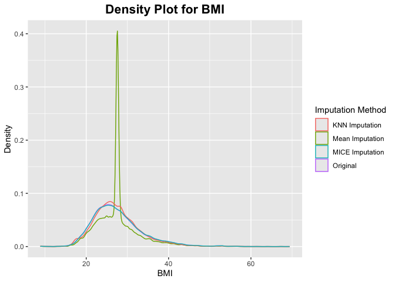

```r
# variables<-data %>%
#   select(where(is.numeric)) %>%
#   names()
variables<-c("PM_BMI_SR",  "PA_TOTAL_SHORT" , "PA_TOTAL_SIT_TIME" )
  # Load the ggplot2 package

# Loop through each variable

 data_rename <- data %>%
  rename_with(~ paste0(. , "_ori"), -ID)
 data_mean_rename <- data_mean %>%
  rename_with(~ paste0(. , "_mean"), -ID)
 imputed_data_KNN_rename <- imputed_data_KNN %>%
  rename_with(~ paste0(. , "_KNN"), -ID)
 imputed_data_mice_c_rename <- imputed_data_mice_c %>%
  rename_with(~ paste0(. , "_mice"), -ID)
#
# # Load the ggplot2 package
# library(ggplot2)

# List of variables to plot
# variables <- c("PA_TOTAL_SHORT", "SDC_GENDER")

# Loop through each variable
combined_data <- data_rename %>%
  full_join(data_mean_rename, by = "ID") %>%
  full_join(imputed_data_KNN_rename, by = "ID") %>%
  full_join(imputed_data_mice_c_rename, by = "ID")
# for (var in variables) {
#   # Create the density plot
#   density_imp <- ggplot(combined_data) +
#     geom_density(aes(x = .combined_data[[paste0(var, "_ori")]], colour = "Original")) +
#     geom_density(aes(x = .combined_data[[paste0(var, "_mean")]], colour = "Mean Imputation")) +
#     geom_density(aes(x = .combined_data[[paste0(var, "_KNN")]], colour = "KNN Imputation")) +
#     geom_density(aes(x = .combined_data[[paste0(var, "_mice")]], colour = "MICE Imputation")) +
#     labs(
#       title = paste("Density Plot for", var),
#       x = var,
#       y = "Density",
#       colour = "Imputation Method"
#     )
#
#   # Display the plot
#   print(density_imp)
# }

density_bmi <- ggplot(combined_data) +
                geom_density(aes(PM_BMI_SR_ori, colour= "Original")) +
                geom_density(aes(PM_BMI_SR_mean, colour= "Mean Imputation")) +
                geom_density(aes(PM_BMI_SR_KNN, colour= "KNN Imputation")) +
                geom_density(aes(PM_BMI_SR_mice, colour= "MICE Imputation"))+
  labs(
    title = "Density Plot for BMI",  # Dynamic title using the variable name
    # subtitle = "Comparison of Imputation Methods",  # Optional subtitle
    # caption = "Data source: Your Dataset",  # Optional caption
    x = "BMI",  # X-axis label
    y = "Density",  # Y-axis label
    colour = "Imputation Method"  # Legend title
  )+
  theme(
  plot.title = element_text(size = 16, face = "bold", hjust = 0.5),  # Center and bold the title
  plot.subtitle = element_text(size = 12, hjust = 0.5),  # Center the subtitle
  plot.caption = element_text(size = 10, face = "italic")  # Italicize the caption
)

plot(density_bmi)
```

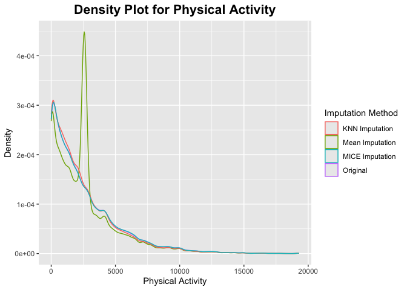

```r
density_short <- ggplot(combined_data) +
                geom_density(aes(PA_TOTAL_SHORT_ori, colour= "Original")) +
                geom_density(aes(PA_TOTAL_SHORT_mean, colour= "Mean Imputation")) +
                geom_density(aes(PA_TOTAL_SHORT_KNN, colour= "KNN Imputation")) +
                geom_density(aes(PA_TOTAL_SHORT_mice, colour= "MICE Imputation"))+
    labs(
    title = "Density Plot for Physical Activity",  # Dynamic title using the variable name
    # subtitle = "Comparison of Imputation Methods",  # Optional subtitle
    # caption = "Data source: Your Dataset",  # Optional caption
    x = "Physical Activity",  # X-axis label
    y = "Density",  # Y-axis label
    colour = "Imputation Method"  # Legend title
  )+
  theme(
  plot.title = element_text(size = 16, face = "bold", hjust = 0.5),  # Center and bold the title
  plot.subtitle = element_text(size = 12, hjust = 0.5),  # Center the subtitle
  plot.caption = element_text(size = 10, face = "italic")  # Italicize the caption
)
plot(density_short)
```

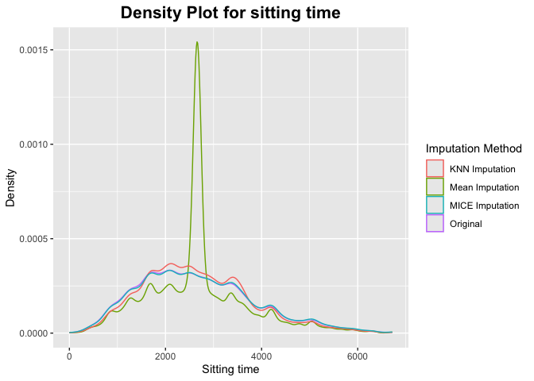

```r
density_sit <- ggplot(combined_data) +
                geom_density(aes(PA_TOTAL_SIT_TIME_ori, colour= "Original")) +
                geom_density(aes(PA_TOTAL_SIT_TIME_mean, colour= "Mean Imputation")) +
                geom_density(aes(PA_TOTAL_SIT_TIME_KNN, colour= "KNN Imputation")) +
                geom_density(aes(PA_TOTAL_SIT_TIME_mice, colour= "MICE Imputation")) +
      labs(
    title = "Density Plot for sitting time",  # Dynamic title using the variable name
    # subtitle = "Comparison of Imputation Methods",  # Optional subtitle
    # caption = "Data source: Your Dataset",  # Optional caption
    x = "Sitting time",  # X-axis label
    y = "Density",  # Y-axis label
    colour = "Imputation Method"  # Legend title
  )+
  theme(
  plot.title = element_text(size = 16, face = "bold", hjust = 0.5),  # Center and bold the title
  plot.subtitle = element_text(size = 12, hjust = 0.5),  # Center the subtitle
  plot.caption = element_text(size = 10, face = "italic")  # Italicize the caption
)
plot(density_sit)
```

4. **Analysis of Imputed Data**
   - Conduct a simple statistical analysis on the imputed datasets to illustrate the downstream effects of different imputation methods.

```r
data_ori<-data %>%
  mutate(source="Original")
data_mean_source<-data_mean %>%
  mutate(source="Meean")
imputed_data_KNN_source<-imputed_data_KNN%>%
  select(-c(ID_imp , PM_BMI_SR_imp, PA_TOTAL_SHORT_imp, PA_TOTAL_SIT_TIME_imp, SDC_EB_ABORIGINAL_imp, SDC_AGE_CALC_imp, SDC_GENDER_imp, WRK_EMPLOYMENT_imp, HS_GEN_HEALTH_imp, NUT_VEG_QTY_imp, NUT_FRUITS_QTY_imp, SMK_CIG_STATUS_imp, ALC_CUR_FREQ_imp, DIS_DEP_EVER_imp, DIS_DIAB_TYPE_imp, ADM_STUDY_ID_imp)) %>%
  mutate(source="KNN")
imputed_data_mice_c_source<-imputed_data_mice_c %>%
  mutate(source="MICE")
combine_long<-rbind(data_ori,data_mean_source, imputed_data_KNN_source, imputed_data_mice_c_source )
```

```r
median_table <- combine_long %>%
   group_by(source) %>%
   summarize(
    BMI = median(PM_BMI_SR, na.rm = TRUE),
    SHORT = mean(PA_TOTAL_SHORT, na.rm = TRUE),
    sit_time = median(PA_TOTAL_SIT_TIME, na.rm = TRUE)
  )
print(median_table)
```

```
## # A tibble: 4 × 4
##   source     BMI SHORT sit_time
##   <chr>    <dbl> <dbl>    <dbl>
## 1 KNN       26.6 2479.    2520
## 2 MICE      26.6 2588.    2520
## 3 Meean     27.5 2574.    2661.
## 4 Original  26.6 2574.    2520
```

- Discuss how the choice of imputation method impacts the analysis results.

```r
 library(broom)
 model_original <- data %>%
   with(lm(PM_BMI_SR ~ PA_TOTAL_SHORT + PA_TOTAL_SHORT +
                  PA_TOTAL_SIT_TIME + SDC_EB_ABORIGINAL +
                  SDC_AGE_CALC + SDC_GENDER+
                  WRK_EMPLOYMENT + HS_GEN_HEALTH +
                  NUT_VEG_QTY + NUT_FRUITS_QTY +
                  SMK_CIG_STATUS + ALC_CUR_FREQ +
                  DIS_DEP_EVER + DIS_DIAB_TYPE +
                  ADM_STUDY_ID))
summary(model_original)
```

```
##
## Call:
## lm(formula = PM_BMI_SR ~ PA_TOTAL_SHORT + PA_TOTAL_SHORT + PA_TOTAL_SIT_TIME +
##     SDC_EB_ABORIGINAL + SDC_AGE_CALC + SDC_GENDER + WRK_EMPLOYMENT +
##     HS_GEN_HEALTH + NUT_VEG_QTY + NUT_FRUITS_QTY + SMK_CIG_STATUS +
##     ALC_CUR_FREQ + DIS_DEP_EVER + DIS_DIAB_TYPE + ADM_STUDY_ID)
##
## Residuals:
##     Min      1Q  Median      3Q     Max
## -20.415  -3.685  -0.764   2.735  39.744
##
## Coefficients:
##                      Estimate Std. Error t value Pr(>|t|)
## (Intercept)         2.739e+01  5.115e-01  53.556  < 2e-16 ***
## PA_TOTAL_SHORT     -1.028e-04  1.691e-05  -6.077 1.25e-09 ***
## PA_TOTAL_SIT_TIME   1.756e-04  3.650e-05   4.811 1.51e-06 ***
## SDC_EB_ABORIGINAL1  4.410e-01  2.300e-01   1.917 0.055192 .
## SDC_AGE_CALC        3.431e-02  4.436e-03   7.734 1.09e-14 ***
## SDC_GENDER2        -1.214e+00  8.885e-02 -13.663  < 2e-16 ***
## WRK_EMPLOYMENT1     1.948e-02  1.023e-01   0.190 0.848981
## HS_GEN_HEALTH2      1.825e-01  3.694e-01   0.494 0.621381
## HS_GEN_HEALTH3     -9.134e-01  3.459e-01  -2.640 0.008287 **
## HS_GEN_HEALTH4     -3.066e+00  3.459e-01  -8.863  < 2e-16 ***
## HS_GEN_HEALTH5     -3.874e+00  3.559e-01 -10.886  < 2e-16 ***
## NUT_VEG_QTY         1.075e-02  2.958e-02   0.364 0.716225
## NUT_FRUITS_QTY     -6.525e-02  3.467e-02  -1.882 0.059848 .
## SMK_CIG_STATUS1     3.433e-01  9.244e-02   3.714 0.000205 ***
## SMK_CIG_STATUS2     7.677e-01  2.711e-01   2.832 0.004634 **
## SMK_CIG_STATUS3     2.488e-01  1.688e-01   1.474 0.140400
## ALC_CUR_FREQ0       4.072e-01  2.531e-01   1.609 0.107708
## ALC_CUR_FREQ1       1.616e-01  2.153e-01   0.751 0.452805
## ALC_CUR_FREQ2       2.668e-01  2.415e-01   1.105 0.269231
## ALC_CUR_FREQ3       1.563e-01  2.233e-01   0.700 0.483945
## ALC_CUR_FREQ4      -5.889e-01  2.273e-01  -2.591 0.009589 **
## ALC_CUR_FREQ5      -2.988e-01  2.137e-01  -1.398 0.162192
## ALC_CUR_FREQ6      -5.661e-01  2.305e-01  -2.456 0.014067 *
## ALC_CUR_FREQ7      -4.715e-01  2.315e-01  -2.037 0.041662 *
## DIS_DEP_EVER1       2.395e-01  1.378e-01   1.738 0.082200 .
## DIS_DEP_EVER2       7.387e-01  5.110e-01   1.446 0.148307
## DIS_DIAB_TYPE1      6.261e-01  5.107e-01   1.226 0.220219
## DIS_DIAB_TYPE2      1.270e+00  1.997e-01   6.362 2.03e-10 ***
## DIS_DIAB_TYPE3      1.679e+00  4.442e-01   3.781 0.000157 ***
## ADM_STUDY_ID2       1.966e+00  1.617e-01  12.157  < 2e-16 ***
## ADM_STUDY_ID3       7.469e-01  1.366e-01   5.469 4.58e-08 ***
## ADM_STUDY_ID5       2.826e+00  2.030e-01  13.921  < 2e-16 ***
## ---
## Signif. codes:  0 '***' 0.001 '**' 0.01 '*' 0.05 '.' 0.1 ' ' 1
##
## Residual standard error: 5.684 on 18666 degrees of freedom
##   (22489 observations deleted due to missingness)
## Multiple R-squared:  0.1024, Adjusted R-squared:  0.1009
## F-statistic: 68.67 on 31 and 18666 DF,  p-value: < 2.2e-16
```

```r
  model_mean <- data_mean %>%
   with(lm(PM_BMI_SR ~ PA_TOTAL_SHORT + PA_TOTAL_SHORT +
                  PA_TOTAL_SIT_TIME + SDC_EB_ABORIGINAL +
                  SDC_AGE_CALC + SDC_GENDER+
                  WRK_EMPLOYMENT + HS_GEN_HEALTH +
                  NUT_VEG_QTY + NUT_FRUITS_QTY +
                  SMK_CIG_STATUS + ALC_CUR_FREQ +
                  DIS_DEP_EVER + DIS_DIAB_TYPE +
                  ADM_STUDY_ID))
 summary(model_mean)
```

```
##
## Call:
## lm(formula = PM_BMI_SR ~ PA_TOTAL_SHORT + PA_TOTAL_SHORT + PA_TOTAL_SIT_TIME +
##     SDC_EB_ABORIGINAL + SDC_AGE_CALC + SDC_GENDER + WRK_EMPLOYMENT +
##     HS_GEN_HEALTH + NUT_VEG_QTY + NUT_FRUITS_QTY + SMK_CIG_STATUS +
##     ALC_CUR_FREQ + DIS_DEP_EVER + DIS_DIAB_TYPE + ADM_STUDY_ID)
##
## Residuals:
##     Min      1Q  Median      3Q     Max
## -19.432  -2.744  -0.363   1.703  40.735
##
## Coefficients:
##                      Estimate Std. Error t value Pr(>|t|)
## (Intercept)         2.816e+01  2.872e-01  98.077  < 2e-16 ***
## PA_TOTAL_SHORT     -7.199e-05  1.065e-05  -6.759 1.41e-11 ***
## PA_TOTAL_SIT_TIME   1.261e-04  2.481e-05   5.080 3.80e-07 ***
## SDC_EB_ABORIGINAL1  2.843e-01  1.353e-01   2.101 0.035668 *
## SDC_AGE_CALC        2.173e-02  2.565e-03   8.468  < 2e-16 ***
## SDC_GENDER2        -8.850e-01  5.364e-02 -16.499  < 2e-16 ***
## WRK_EMPLOYMENT1    -1.221e-02  5.896e-02  -0.207 0.835958
## HS_GEN_HEALTH2     -2.515e-01  1.968e-01  -1.278 0.201400
## HS_GEN_HEALTH3     -9.802e-01  1.834e-01  -5.345 9.07e-08 ***
## HS_GEN_HEALTH4     -2.522e+00  1.833e-01 -13.761  < 2e-16 ***
## HS_GEN_HEALTH5     -3.038e+00  1.901e-01 -15.985  < 2e-16 ***
## NUT_VEG_QTY         1.806e-02  1.729e-02   1.045 0.296172
## NUT_FRUITS_QTY     -5.177e-02  2.026e-02  -2.555 0.010612 *
## SMK_CIG_STATUS1     2.328e-01  5.560e-02   4.186 2.84e-05 ***
## SMK_CIG_STATUS2     3.144e-01  1.630e-01   1.929 0.053771 .
## SMK_CIG_STATUS3     2.049e-02  9.312e-02   0.220 0.825810
## ALC_CUR_FREQ0       2.751e-01  1.436e-01   1.916 0.055425 .
## ALC_CUR_FREQ1       1.308e-01  1.171e-01   1.117 0.264102
## ALC_CUR_FREQ2       1.445e-01  1.387e-01   1.042 0.297472
## ALC_CUR_FREQ3       4.597e-03  1.271e-01   0.036 0.971141
## ALC_CUR_FREQ4      -4.623e-01  1.298e-01  -3.563 0.000367 ***
## ALC_CUR_FREQ5      -3.469e-01  1.210e-01  -2.868 0.004135 **
## ALC_CUR_FREQ6      -3.818e-01  1.315e-01  -2.903 0.003701 **
## ALC_CUR_FREQ7      -2.629e-01  1.331e-01  -1.975 0.048292 *
## DIS_DEP_EVER1       1.065e-01  8.036e-02   1.325 0.185251
## DIS_DEP_EVER2       3.920e-01  2.490e-01   1.575 0.115378
## DIS_DIAB_TYPE1      8.212e-01  2.837e-01   2.895 0.003800 **
## DIS_DIAB_TYPE2      1.013e+00  1.136e-01   8.921  < 2e-16 ***
## DIS_DIAB_TYPE3      1.074e+00  2.451e-01   4.382 1.18e-05 ***
## ADM_STUDY_ID2       1.221e+00  9.969e-02  12.244  < 2e-16 ***
## ADM_STUDY_ID3       3.109e-01  8.384e-02   3.708 0.000209 ***
## ADM_STUDY_ID5       1.700e+00  1.031e-01  16.490  < 2e-16 ***
## ---
## Signif. codes:  0 '***' 0.001 '**' 0.01 '*' 0.05 '.' 0.1 ' ' 1
##
## Residual standard error: 5.002 on 41155 degrees of freedom
## Multiple R-squared:  0.06947,    Adjusted R-squared:  0.06877
## F-statistic: 99.12 on 31 and 41155 DF,  p-value: < 2.2e-16
```

```r
model_KNN <- imputed_data_KNN %>%
   with(lm(PM_BMI_SR ~ PA_TOTAL_SHORT + PA_TOTAL_SHORT +
                  PA_TOTAL_SIT_TIME + SDC_EB_ABORIGINAL +
                  SDC_AGE_CALC + SDC_GENDER+
                  WRK_EMPLOYMENT + HS_GEN_HEALTH +
                  NUT_VEG_QTY + NUT_FRUITS_QTY +
                  SMK_CIG_STATUS + ALC_CUR_FREQ +
                  DIS_DEP_EVER + DIS_DIAB_TYPE +
                  ADM_STUDY_ID))
#model for KNNN imputation
 summary(model_KNN)
```

```
##
## Call:
## lm(formula = PM_BMI_SR ~ PA_TOTAL_SHORT + PA_TOTAL_SHORT + PA_TOTAL_SIT_TIME +
##     SDC_EB_ABORIGINAL + SDC_AGE_CALC + SDC_GENDER + WRK_EMPLOYMENT +
##     HS_GEN_HEALTH + NUT_VEG_QTY + NUT_FRUITS_QTY + SMK_CIG_STATUS +
##     ALC_CUR_FREQ + DIS_DEP_EVER + DIS_DIAB_TYPE + ADM_STUDY_ID)
##
## Residuals:
##     Min      1Q  Median      3Q     Max
## -19.949  -3.513  -0.710   2.667  41.391
##
## Coefficients:
##                      Estimate Std. Error t value Pr(>|t|)
## (Intercept)         2.816e+01  3.110e-01  90.544  < 2e-16 ***
## PA_TOTAL_SHORT     -8.685e-05  1.127e-05  -7.705 1.34e-14 ***
## PA_TOTAL_SIT_TIME   1.301e-04  2.505e-05   5.194 2.07e-07 ***
## SDC_EB_ABORIGINAL1  2.568e-01  1.417e-01   1.813 0.069870 .
## SDC_AGE_CALC        2.806e-02  2.829e-03   9.916  < 2e-16 ***
## SDC_GENDER2        -1.111e+00  5.933e-02 -18.719  < 2e-16 ***
## WRK_EMPLOYMENT1    -6.744e-02  6.402e-02  -1.053 0.292129
## HS_GEN_HEALTH2     -4.274e-02  2.147e-01  -0.199 0.842239
## HS_GEN_HEALTH3     -8.354e-01  2.002e-01  -4.173 3.02e-05 ***
## HS_GEN_HEALTH4     -2.885e+00  2.006e-01 -14.380  < 2e-16 ***
## HS_GEN_HEALTH5     -3.628e+00  2.078e-01 -17.457  < 2e-16 ***
## NUT_VEG_QTY         3.273e-02  1.884e-02   1.737 0.082365 .
## NUT_FRUITS_QTY     -9.409e-03  2.185e-02  -0.431 0.666743
## SMK_CIG_STATUS1     3.362e-01  6.055e-02   5.553 2.83e-08 ***
## SMK_CIG_STATUS2     3.271e-01  1.771e-01   1.847 0.064779 .
## SMK_CIG_STATUS3     3.464e-02  1.011e-01   0.343 0.731955
## ALC_CUR_FREQ0       2.832e-01  1.526e-01   1.856 0.063478 .
## ALC_CUR_FREQ1       1.330e-01  1.271e-01   1.046 0.295420
## ALC_CUR_FREQ2       3.123e-01  1.473e-01   2.119 0.034074 *
## ALC_CUR_FREQ3       4.205e-02  1.348e-01   0.312 0.755126
## ALC_CUR_FREQ4      -5.670e-01  1.382e-01  -4.103 4.08e-05 ***
## ALC_CUR_FREQ5      -5.587e-01  1.283e-01  -4.355 1.34e-05 ***
## ALC_CUR_FREQ6      -4.983e-01  1.398e-01  -3.564 0.000366 ***
## ALC_CUR_FREQ7      -4.600e-01  1.416e-01  -3.248 0.001162 **
## DIS_DEP_EVER1       1.360e-01  8.582e-02   1.585 0.113033
## DIS_DEP_EVER2       9.404e-02  2.475e-01   0.380 0.704002
## DIS_DIAB_TYPE1      8.470e-01  3.116e-01   2.719 0.006559 **
## DIS_DIAB_TYPE2      1.128e+00  1.238e-01   9.114  < 2e-16 ***
## DIS_DIAB_TYPE3      1.666e+00  2.684e-01   6.206 5.49e-10 ***
## ADM_STUDY_ID2       1.524e+00  1.097e-01  13.893  < 2e-16 ***
## ADM_STUDY_ID3      -6.900e-02  9.241e-02  -0.747 0.455260
## ADM_STUDY_ID5       2.385e+00  1.136e-01  20.998  < 2e-16 ***
## ---
## Signif. codes:  0 '***' 0.001 '**' 0.01 '*' 0.05 '.' 0.1 ' ' 1
##
## Residual standard error: 5.51 on 41155 degrees of freedom
## Multiple R-squared:  0.1003, Adjusted R-squared:  0.0996
## F-statistic:   148 on 31 and 41155 DF,  p-value: < 2.2e-16
```

```r
 model_mice <- imputed_data_mice_c %>%
   with(lm(PM_BMI_SR ~ PA_TOTAL_SHORT + PA_TOTAL_SHORT +
                  PA_TOTAL_SIT_TIME + SDC_EB_ABORIGINAL +
                  SDC_AGE_CALC + SDC_GENDER+
                  WRK_EMPLOYMENT + HS_GEN_HEALTH +
                  NUT_VEG_QTY + NUT_FRUITS_QTY +
                  SMK_CIG_STATUS + ALC_CUR_FREQ +
                  DIS_DEP_EVER + DIS_DIAB_TYPE +
                  ADM_STUDY_ID))
#model for KNNN imputation
 summary(model_mice)
```

```
##
## Call:
## lm(formula = PM_BMI_SR ~ PA_TOTAL_SHORT + PA_TOTAL_SHORT + PA_TOTAL_SIT_TIME +
##     SDC_EB_ABORIGINAL + SDC_AGE_CALC + SDC_GENDER + WRK_EMPLOYMENT +
##     HS_GEN_HEALTH + NUT_VEG_QTY + NUT_FRUITS_QTY + SMK_CIG_STATUS +
##     ALC_CUR_FREQ + DIS_DEP_EVER + DIS_DIAB_TYPE + ADM_STUDY_ID)
##
## Residuals:
##     Min      1Q  Median      3Q     Max
## -21.174  -3.782  -0.810   2.833  41.317
##
## Coefficients:
##                      Estimate Std. Error t value Pr(>|t|)
## (Intercept)         2.825e+01  3.331e-01  84.824  < 2e-16 ***
## PA_TOTAL_SHORT     -8.629e-05  1.152e-05  -7.489 7.10e-14 ***
## PA_TOTAL_SIT_TIME   1.355e-04  2.499e-05   5.422 5.94e-08 ***
## SDC_EB_ABORIGINAL1  5.612e-01  1.512e-01   3.712 0.000206 ***
## SDC_AGE_CALC        3.221e-02  3.030e-03  10.629  < 2e-16 ***
## SDC_GENDER2        -1.209e+00  6.314e-02 -19.154  < 2e-16 ***
## WRK_EMPLOYMENT1    -4.064e-02  6.849e-02  -0.593 0.552949
## HS_GEN_HEALTH2     -4.471e-01  2.279e-01  -1.961 0.049830 *
## HS_GEN_HEALTH3     -1.468e+00  2.128e-01  -6.898 5.34e-12 ***
## HS_GEN_HEALTH4     -3.592e+00  2.132e-01 -16.844  < 2e-16 ***
## HS_GEN_HEALTH5     -4.355e+00  2.209e-01 -19.713  < 2e-16 ***
## NUT_VEG_QTY         3.269e-02  1.970e-02   1.659 0.097110 .
## NUT_FRUITS_QTY     -6.779e-02  2.307e-02  -2.938 0.003300 **
## SMK_CIG_STATUS1     2.919e-01  6.435e-02   4.536 5.74e-06 ***
## SMK_CIG_STATUS2     5.102e-01  1.844e-01   2.766 0.005672 **
## SMK_CIG_STATUS3    -7.783e-02  1.064e-01  -0.731 0.464689
## ALC_CUR_FREQ0       2.258e-01  1.641e-01   1.376 0.168908
## ALC_CUR_FREQ1       7.947e-02  1.371e-01   0.579 0.562266
## ALC_CUR_FREQ2       8.622e-02  1.583e-01   0.545 0.585928
## ALC_CUR_FREQ3       9.775e-03  1.452e-01   0.067 0.946346
## ALC_CUR_FREQ4      -6.336e-01  1.484e-01  -4.270 1.96e-05 ***
## ALC_CUR_FREQ5      -5.496e-01  1.384e-01  -3.972 7.14e-05 ***
## ALC_CUR_FREQ6      -5.467e-01  1.505e-01  -3.634 0.000280 ***
## ALC_CUR_FREQ7      -3.817e-01  1.524e-01  -2.504 0.012273 *
## DIS_DEP_EVER1       2.938e-01  8.903e-02   3.300 0.000968 ***
## DIS_DEP_EVER2       2.218e-02  2.796e-01   0.079 0.936780
## DIS_DIAB_TYPE1      7.653e-01  3.266e-01   2.343 0.019126 *
## DIS_DIAB_TYPE2      1.566e+00  1.304e-01  12.009  < 2e-16 ***
## DIS_DIAB_TYPE3      1.659e+00  2.818e-01   5.887 3.96e-09 ***
## ADM_STUDY_ID2       1.795e+00  1.166e-01  15.392  < 2e-16 ***
## ADM_STUDY_ID3       6.633e-01  9.820e-02   6.755 1.44e-11 ***
## ADM_STUDY_ID5       3.537e+00  1.207e-01  29.298  < 2e-16 ***
## ---
## Signif. codes:  0 '***' 0.001 '**' 0.01 '*' 0.05 '.' 0.1 ' ' 1
##
## Residual standard error: 5.855 on 41155 degrees of freedom
## Multiple R-squared:  0.1094, Adjusted R-squared:  0.1087
## F-statistic: 163.1 on 31 and 41155 DF,  p-value: < 2.2e-16
```

5. **Interpretation and Reporting**
   - Provide a detailed comparison of the methods, discussing their strengths, weaknesses, and suitability for the dataset. # Mean/Median/Mode Imputation

Method: Replace missing values with the mean, median, or mode of the observed data. Impact: Advantages: Simple and easy to implement. Preserves the sample size. Disadvantages: Reduces variability in the data, leading to underestimation of variance. Can distort relationships between variables (e.g., correlations, regression coefficients). Ignores the uncertainty of the imputed values. Use Case: Suitable for preliminary analysis or when the proportion of missing data is very small.

# k-Nearest Neighbors (KNN) Imputation

Method: Replace missing values with the average (or weighted average) of the k-nearest neighbors in the feature space. Advantages: Captures local patterns in the data. Preserves relationships between variables better than mean imputation. Disadvantages: Computationally expensive for large datasets. Sensitive to the choice of k and the distance metric. May introduce bias if the data has a complex structure. Use Case: Useful for datasets with complex relationships and moderate missingness.

# Multiple Imputation by Chained Equations (MICE)

Method: Generate multiple imputed datasets by modeling each variable with missing data conditional on other variables. Impact: Advantages: Accounts for uncertainty in the imputed values by generating multiple datasets. Preserves relationships between variables and the variability of the data. Flexible and can handle different types of variables (continuous, categorical). Disadvantages: Computationally intensive. Requires careful specification of the imputation model. Use Case: Ideal for datasets with complex missing data mechanisms and when unbiased estimates of uncertainty are needed.

- Reflect on the challenges of handling missing data in health research.

Bias: The analysis may produce biased estimates if missingness is not random (MAR or MNAR). Reduced Statistical Power: Missing data reduces the adequate sample size, leading to less precise estimates and lower power to detect significant effects. Loss of Generalizability: If the missing data pattern is related to specific subgroups, the results may not be generalizable to the entire population. Challenge: Ensuring that the analysis remains valid and generalizable despite missing data.

## References

Bennett, Derrick A. 2001. “How Can i Deal with Missing Data in My Study?” *Australian and New Zealand Journal of Public Health* 25 (5): 464–69.

Lee, Katherine J, and John B Carlin. 2012. “Recovery of Information from Multiple Imputation: A Simulation Study.” *Emerging Themes in Epidemiology* 9: 1–10.

Mishra, Sukhdev, and Diwakar Khare. 2014. “On Comparative Performance of Multiple Imputation Methods for Moderate to Large Proportions of Missing Data in Clinical Trials: A Simulation Study.” *J Med Stat Inform* 2 (1): 9.

Schafer, Joseph L. 1999. “Multiple Imputation: A Primer.” *Statistical Methods in Medical Research* 8 (1): 3–15.